# Evaluating Goal-oriented End-to-End Dialog Systems

(*Antoine Bordes, Y-Lan Boureau, Jason Weston*)  
Presentation: *Dan Pressel*

February 8th, 2017

# Dialog Systems at Present

- Most useful dialog systems currently goal-oriented, transactional
  - Dialog state as set of slots to be filled during dialog (slot-filling)
  - Conversation modeling as POMDP (Young et al., 2013).
  - Many hand-crafted features for state and action space representation
- Hard to scale to new domains
  - Impossible to encode all features and slots users might refer to in conversation
  - Restricts usage to narrow domains

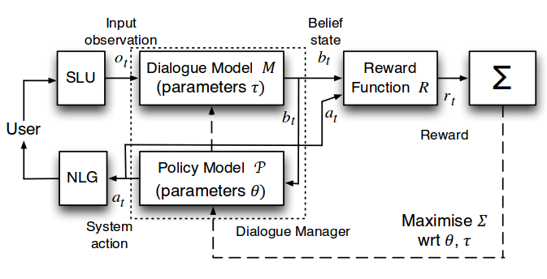

POMDP Model

# E2E Dialog Systems

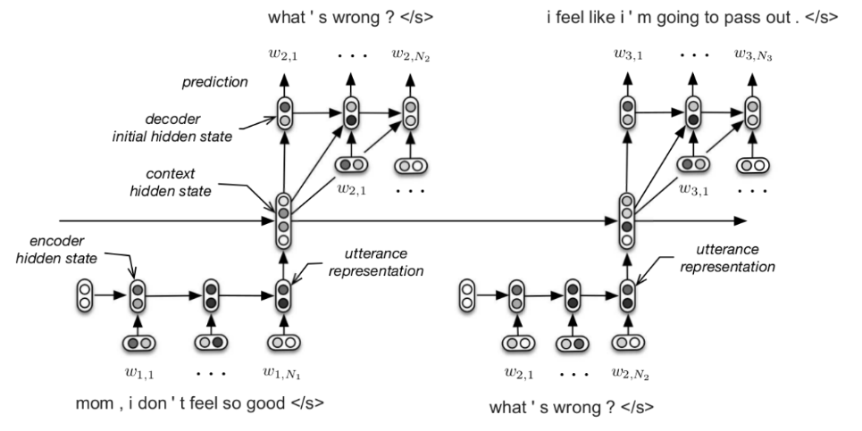

E2E Model

# E2E for Goal-Oriented Conversations?

- Usually based on NNs
- Go from dialog history to next response
  - Intermediate task/state not available at train/test
- Escape limitations of domain/dialog state structure
  - Should be easier to do domain adaptation
- Demonstrated for “chit-chat”
  - But how well do they work on goal-oriented dialogs?

# E2E Evaluation Methods

- Human Evaluations (AMT, etc.)
  - PROS: test fluency, task completion, actual task
  - CONS: costly, not reproducible
- Automatic (BLEU, perplexity, etc.)
  - PROS: fast, scalable, reproducible
  - CONS: not correlated with human evaluation

# Restaurant booking in 5 tasks

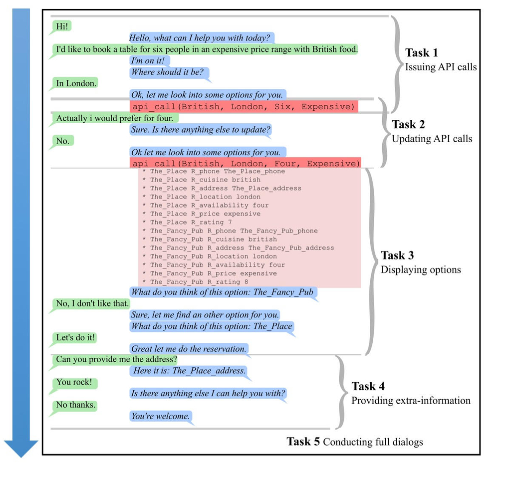

# bAbI dialog: Simulated tasks for E2E dialog systems

- Introduces a new dataset
  - Full control of data
  - Easy diagnostics
  - No humans in the loop
  - No indirect metrics (BLEU, ROUGE, etc.)
  - Assess ability to complete goal-oriented tasks
  - Open source (https://research.fb.com/projects/babi/)

# Datasets

- bAbI dialog sets
  - Restaurant booking domain
  - 5 simulated tasks (T1-T5)
  - 1 task converted from Dialog State Tracking Challenge 2 (DSCT2) (T6)
- Also proprietary concierge data
  - Users make requests through text-based chat interface handled by humans
  - All conversations between native English speakers
  - Validate bAbI as proxy for real dataset

# bAbI dialog creation

# Task 1: Issuing API calls

- User request with 0-4 required fields (sampled uniformly)
- Bot must ask Qs for filling missing fields, then generate correct API call
  - Asks for information in deterministic order (makes prediction possible)

```
1 hello    hello what can i help you with today
2 can you book a table for six people with french food  i'm on it
3 <SILENCE>     where should it be
4 in bombay     which price range are looking for
5 i am looking for a cheap restaurant   ok let me look into some options for you
6 <SILENCE>     api_call french bombay six cheap

1 hi    hello what can i help you with today
2 can you make a restaurant reservation with italian cuisine for six people in a
cheap price range      i'm on it
3 <SILENCE>     where should it be
4 rome please   ok let me look into some options for you
5 <SILENCE>     api_call italian rome six cheap
```

# Task 2: Updating API calls

- Start by issuing API call
  - User asks to update requests between 1-4 times
  - Order of updates is random
  - Bot asks user if done with updates
  - Bot isues updated API call

```
1 hello    hello what can i help you with today
2 i'd like to book a table with british food in a moderate price range in bombay
for two people    i'm on it
3 <SILENCE>     ok let me look into some options for you
4 <SILENCE>     api_call british bombay two moderate
5 instead could it be in a expensive price range        sure is there anything else to update
6 instead could it be with indian cuisine       sure is there anything else to update
7 actually i would prefer for six people        sure is there anything else to update
8 instead could it be in madrid    sure is there anything else to update
9 no    ok let me look into some options for you
10 <SILENCE>    api_call indian madrid six expensive
11 thanks       you're welcome
```

# Task 3: Displaying options

- Given user request
  - Query KB using call
  - Add facts resulting from call to dialog history
  - Bot proposes options to users by listing restaurant names sorted rating desc until users accept
  - User has a 25% chance of accepting
  - If user accepts, bot should stop displaying options, otherwise keep proposing
  - User always accepts if last choice
  - Examples with API calls retrieving >= 3 options

# Task 3: Displaying options (listing)

```
1 resto_london_expensive_spanish_6stars R_phone resto_london_expensive_spanish_6stars_phone
2 resto_london_expensive_spanish_6stars R_cuisine spanish
3 resto_london_expensive_spanish_6stars R_address resto_london_expensive_spanish_6stars_address
4 resto_london_expensive_spanish_6stars R_location london
5 resto_london_expensive_spanish_6stars R_number eight
6 resto_london_expensive_spanish_6stars R_price expensive
7 resto_london_expensive_spanish_6stars R_rating 6
...
22 hi   hello what can i help you with today
23 can you make a restaurant reservation for eight people in a expensive price range in london
with spanish food    i'm on it
24 <SILENCE>    ok let me look into some options for you
25 <SILENCE>    what do you think of this option: resto_london_expensive_spanish_6stars
26 do you have something else   sure let me find an other option for you
27 <SILENCE>    what do you think of this option: resto_london_expensive_spanish_5stars
28 that looks great     great let me do the reservation
```

# Task 4: Providing extra information

- Given user request
  - Sample a restaurant, start dialog as if users agreed already to book there
  - Add all KB facts corresponding to dialog
  - Users ask for phone #, address, or both with probs 25%, 25%, 50%
  - Bot must learn to use KB facts to answer (order non-deterministic)

```
1 resto_bombay_cheap_french_5stars R_phone resto_bombay_cheap_french_5stars_phone
2 resto_bombay_cheap_french_5stars R_cuisine french
3 resto_bombay_cheap_french_5stars R_address resto_bombay_cheap_french_5stars_address
4 resto_bombay_cheap_french_5stars R_location bombay
5 resto_bombay_cheap_french_5stars R_number six
6 resto_bombay_cheap_french_5stars R_price cheap
7 resto_bombay_cheap_french_5stars R_rating 5
8 hi    hello what can i help you with today
9 may i have a table at resto_bombay_cheap_french_5stars    great let me do the reservation
10 may i have the phone number of the restaurant    here it is resto_bombay_cheap_french_5stars_phone
11 may i have the address of the restaurant     here it is resto_bombay_cheap_french_5stars_address
```

# Task 5: Conducting full dialogs (listing)

- Combine tasks 1-4 to generate full dialogs

  ```
  1 hi    hello what can i help you with today
  2 i'd like to book a table for four in a expensive price range  i'm on it
  3 <SILENCE>     any preference on a type of cuisine
  4 with indian food      where should it be
  5 in london     ok let me look into some options for you
  6 <SILENCE>     api_call indian london four expensive
  7 actually i would prefer in paris    sure is there anything else to update
  8 actually i would prefer in a moderate price range    sure is there anything else to update
  9 no    ok let me look into some options for you
  10 <SILENCE>    api_call indian paris four moderate
  11 resto_paris_moderate_indian_1stars R_phone resto_paris_moderate_indian_1stars_phone
  12 resto_paris_moderate_indian_1stars R_cuisine indian
  ...
  18 resto_paris_moderate_indian_8stars R_phone resto_paris_moderate_indian_8stars_phone
  ...
  25 resto_paris_moderate_indian_5stars R_phone resto_paris_moderate_indian_5stars_phone
  ...
  32 <SILENCE>    what do you think of this option: resto_paris_moderate_indian_8stars
  33 no i don't like that sure let me find an other option for you
  34 <SILENCE>    what do you think of this option: resto_paris_moderate_indian_5stars
  35 let's do it  great let me do the reservation
  36 may i have the phone number of the restaurant    here it is resto_paris_moderate_indian_5stars_phone
  37 thank you    is there anything i can help you with
  38 no thanks    you're welcome
  ```

# bAbI dialog evaluation

- OOV word test
  - 2nd test set with entities (location, cusine type) not found in training set
- Next Utterance Classification (NUC)
  - Use prediction instead of Generation
  - Select correct response from candidate list
  - Removes difficulty of evaluation of LM
- Per-response and per-dialog accuracy
  - Per-response counts each correct response
  - Per-dialog counts task completion (all correct) (per-dialog)

# bAbI dialog stats

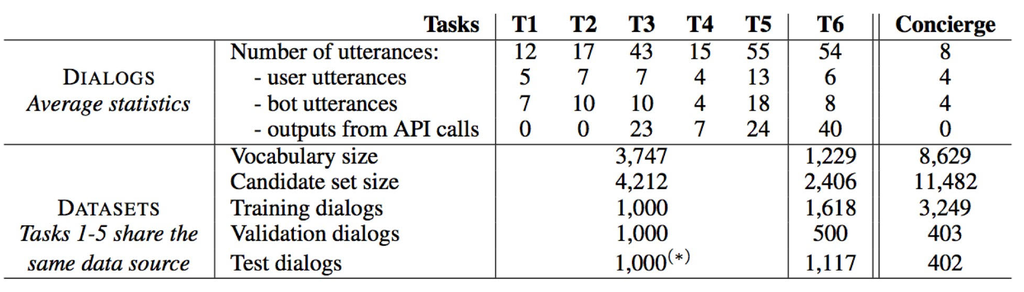

# Evaluation of Models

- Rule-based
- Classical IR
  - TF-IDF
  - Nearest Neighbor
- Embeddings
- End-to-End Memory Networks (MemNN)

# Classical IR Methods

- TF-IDF model
  - For each possible candidate response, compute matching score between input (last-utterance OR conversation history) & response
  - Rank by score (TF-IDF-weighted cosine sim of BoWs)
- Nearest Neighbor Model
  - Using input (last-utterance), find most similar conversation in training and output the response from that
  - Training set is (utterance, response) pairs selected using word overlap scoring
  - When several responses for same utterance, sort decreasing co-occurrence frequency

# Supervised Embeddings Architecture

- Use supervised word embedding models for scoring
  - (conversation history, response) pairs
  - Trained directly to predict response from conversation history
  - Candidate response **y** is scored against input **x**
  - **A** and **B** are embedding matrices with size **d x V**

  $f(x, y) = (Ax)^{T} By$
- Train with margin ranking loss **m** and negative response sampling $f(x,y) > m + f(x, \bar{y})$

# E2E Memory Network architecture (Sukhbaatar et. al., 2015)

- (a): Single layer architecture (1 hop MemNN)
- (b): Multi-layer architecture (multi-hop)

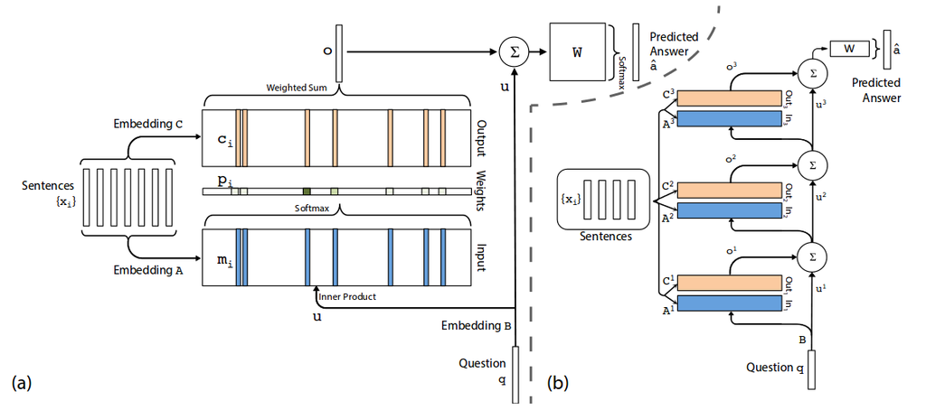